# Diagnosed diabetes in US adults

Dataset 10: NHANES adults (2009-10 and 2011-12 extract)

RSR feasibility analysis

2026-08-03

# Introduction

The National Health and Nutrition Examination Survey (NHANES) is a continuous cross-sectional survey of the civilian non-institutionalised US population, pairing a household interview with a standardised examination. This teaching extract holds 488 adults aged 21 to 80 from the 2009-10 and 2011-12 cycles, of whom 57 (11.7%) report a doctor’s diagnosis of diabetes. Type 2 diabetes is one of the most consequential chronic conditions in adult populations, and identifying which routinely collected characteristics mark higher prevalence supports targeted screening.

**Aim.** Among these US adults, we examined which of age, sex, BMI, recreational physical activity and smoking history are independently associated with having a diagnosis of diabetes, mutually adjusting for the others.

This is a *Purpose 3* analysis: several predictors are of interest and the question is which remain associated with the outcome after mutual adjustment.

# Methods

**Data source.** NHANES 2009-10 and 2011-12, a complex multistage probability sample of the US civilian non-institutionalised population. This extract contains 488 adults with 31 variables. Height and weight were measured in the mobile examination centre; diabetes status is self-reported diagnosis by a doctor, collected in the household interview.

**Variables.** The outcome is `diabetes`, a binary indicator where the **event is a reported doctor’s diagnosis of diabetes** (57 events in the full file). Predictors are age (years), sex (reference female), BMI (kg/m2), recreational moderate or vigorous physical activity (reference no) and ever having smoked 100 cigarettes (reference no).

**The predictor set is deliberately small.** With 57 events in the file, the conventional rule of ten events per estimated parameter supports about **five parameters**. The five predictors above cost exactly five parameters (all are continuous or binary, so none consumes more than one degree of freedom). Adding race/ethnicity, education or marital status - each of which would cost four or five further parameters - would take the model well past what the data can support and produce unstable, over-optimistic estimates. In the case of race/ethnicity it would do worse than that: the “Other” category contains 25 participants and **none** of them reports diabetes, so adding race produces complete separation and a coefficient that diverges. This budget was fixed before any model was fitted.

`weight_kg` and `height_cm` are excluded because `bmi` is exactly `weight_kg / (height_cm/100)^2` in this file. `obese` is excluded because it is exactly `bmi >= 30` and would be collinear with BMI while discarding information.

**Statistical analysis.** `glm(family = binomial)`, justified because the outcome is binary. We fitted a univariable model for each predictor first, then a single multivariable model containing all of them. Predictors were chosen in advance on subject-matter grounds, not by significance. Coefficients are exponentiated and reported as odds ratios with 95% confidence intervals; significance threshold 0.05. Model adequacy was assessed with `performance::check_model()`, focusing on binned residuals, collinearity, influential observations and events per parameter. Models are **unweighted**: the NHANES survey weights, strata and primary sampling units are not carried in this extract, so no result here is a nationally representative estimate. Analysis used R version 4.6.0 (2026-04-24) with tidyverse, gtsummary and performance.

**Missing data.** Complete-case analysis: 485 of 488 rows were analysed (3 dropped, all for missing BMI), leaving 56 events. This is the least attrition of any model in this dataset because none of the five predictors has meaningful missingness. Only 172 of 488 rows are complete on *every* variable in the file, so a larger predictor set would have cost far more than 3 rows - another reason to keep the model small.

# Results

## Sample characteristics

**Table 1. Sample characteristics by diabetes status.**

| **Characteristic** | **N** | **No diabetes** N = 429<sup>1</sup> | **Diabetes** N = 56<sup>1</sup> |
| --- | --- | --- | --- |
| Age (years) | 485 | 47 (34, 60) | 63 (54, 71) |
| Sex | 485 |  |  |
| Female |  | 228 (53%) | 32 (57%) |
| Male |  | 201 (47%) | 24 (43%) |
| BMI (kg/m2) | 485 | 28 (25, 32) | 32 (27, 39) |
| Recreationally physically active | 485 | 225 (52%) | 15 (27%) |
| Ever smoked 100+ cigarettes | 485 | 196 (46%) | 27 (48%) |

<sup>1</sup> Median (Q1, Q3); n (%)

Participants with diagnosed diabetes are markedly older (median 63 versus 47 years) and heavier (median BMI 32 versus 28 kg/m2) than those without, and only about a quarter report recreational physical activity compared with about half of those without diabetes. Sex and smoking history look similar in the two groups.

## Exploratory figure

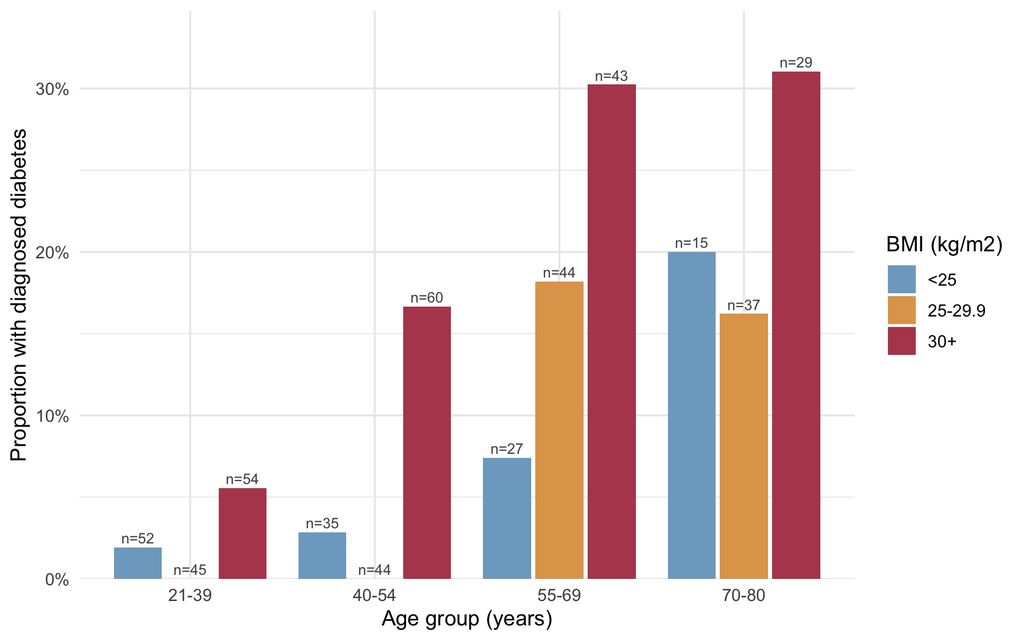

Figure 1. Proportion with diagnosed diabetes by age group and BMI category.

Diabetes prevalence rises steeply with both age and BMI and the two effects compound: it is near zero in normal-weight adults under 40 and approaches a third in obese adults aged 55 and over. (BMI category is used here for display only; BMI enters the models as a continuous variable.)

## Univariable models

| **Characteristic** | **N** | **OR** | **95% CI** | **p-value** |
| --- | --- | --- | --- | --- |
| Age (years) | 485 | 1.05 | 1.03, 1.08 | <0.001 |
| Sex | 485 |  |  |  |
| Female |  | — | — |  |
| Male |  | 0.85 | 0.48, 1.49 | 0.6 |
| BMI (kg/m2) | 485 | 1.10 | 1.06, 1.14 | <0.001 |
| Recreationally physically active | 485 |  |  |  |
| No |  | — | — |  |
| Yes |  | 0.33 | 0.17, 0.60 | <0.001 |
| Ever smoked 100+ cigarettes | 485 |  |  |  |
| No |  | — | — |  |
| Yes |  | 1.11 | 0.63, 1.93 | 0.7 |

Abbreviations: CI = Confidence Interval, OR = Odds Ratio

Three predictors show strong crude associations. Each additional year of age multiplies the odds of diagnosed diabetes by OR 1.05 (95% CI 1.03 to 1.08) (p <0.001), which compounds to roughly 1.7-fold per decade. Each additional kg/m2 of BMI multiplies the odds by OR 1.10 (95% CI 1.06 to 1.14) (p <0.001), i.e. about 1.6-fold per 5 kg/m2. Recreational physical activity is associated with OR 0.33 (95% CI 0.17 to 0.60) (p <0.001), a two-thirds lower odds. Sex (OR 0.85 (95% CI 0.48 to 1.49), p = 0.573) and smoking (OR 1.11 (95% CI 0.63 to 1.93), p = 0.721) show no crude association.

## Why adjustment is needed

**Age** is the primary confounder of the physical-activity association. Older adults exercise less and, independently, have far higher diabetes prevalence because incidence accumulates over the life course; the crude two-thirds lower odds among active participants is therefore partly just the youth of the active group. **BMI** is the second confounder, and it works on the activity association in the same direction: physically active people are leaner, and adiposity is the strongest modifiable driver of type 2 diabetes, so the crude activity odds ratio also carries a body-composition difference. BMI additionally confounds the sex comparison, since BMI distributions differ between men and women in this sample. Mutual adjustment lets each odds ratio be read as a comparison between participants of the same age, sex, body mass, activity level and smoking history.

## Multivariable model

| **Characteristic** | **OR** | **95% CI** | **p-value** |
| --- | --- | --- | --- |
| Age (years) | 1.06 | 1.04, 1.08 | <0.001 |
| Sex |  |  |  |
| Female | — | — |  |
| Male | 1.12 | 0.59, 2.14 | 0.7 |
| BMI (kg/m2) | 1.11 | 1.07, 1.16 | <0.001 |
| Recreationally physically active |  |  |  |
| No | — | — |  |
| Yes | 0.53 | 0.26, 1.02 | 0.061 |
| Ever smoked 100+ cigarettes |  |  |  |
| No | — | — |  |
| Yes | 1.01 | 0.54, 1.90 | >0.9 |

Abbreviations: CI = Confidence Interval, OR = Odds Ratio

**Model fit: multivariable logistic model for diabetes**

| Statistic | Value |
| --- | --- |
| Complete-case N | 485 |
| Events (diabetes = 1) | 56 |
| Parameters (excl. intercept) | 5 |
| Events per parameter | 11.2 |
| AIC (null model) | 349.1 |
| AIC (full model) | 291.3 |
| Tjur's R-squared | 0.158 |

The model has 56 events for 5 estimated parameters, i.e. **11.2 events per parameter**, which clears the conventional minimum of ten - but only just, and only because the predictor set was capped at five in advance. AIC falls from 349.1 for the intercept-only model to 291.3, a drop of 57.8, so the predictors collectively carry real information; Tjur’s R-squared is 0.158.

Among participants of the same sex, BMI, activity level and smoking history, each additional year of age multiplies the odds of diagnosed diabetes by OR 1.06 (95% CI 1.04 to 1.08) (p <0.001). Among participants alike on everything else, each additional kg/m2 of BMI multiplies the odds by OR 1.11 (95% CI 1.07 to 1.16) (p <0.001) - about 1.7-fold per 5 kg/m2. Physical activity is associated with OR 0.53 (95% CI 0.26 to 1.02) (p = 0.061), no longer significant at the 0.05 level. Sex (OR 1.12 (95% CI 0.59 to 2.14)) and smoking (OR 1.01 (95% CI 0.54 to 1.90)) remain null. These are associations among the participants observed, not effects of intervening.

## Unadjusted versus adjusted

**Table 2. Unadjusted and adjusted odds ratios.**

| **Characteristic** | **Unadjusted** **N** | **Unadjusted** **OR** | **Unadjusted** **95% CI** | **Unadjusted** **p-value** | **Adjusted** **OR** | **Adjusted** **95% CI** | **Adjusted** **p-value** |
| --- | --- | --- | --- | --- | --- | --- | --- |
| Age (years) | 485 | 1.05 | 1.03, 1.08 | <0.001 | 1.06 | 1.04, 1.08 | <0.001 |
| Sex | 485 |  |  |  |  |  |  |
| Female |  | — | — |  | — | — |  |
| Male |  | 0.85 | 0.48, 1.49 | 0.6 | 1.12 | 0.59, 2.14 | 0.7 |
| BMI (kg/m2) | 485 | 1.10 | 1.06, 1.14 | <0.001 | 1.11 | 1.07, 1.16 | <0.001 |
| Recreationally physically active | 485 |  |  |  |  |  |  |
| No |  | — | — |  | — | — |  |
| Yes |  | 0.33 | 0.17, 0.60 | <0.001 | 0.53 | 0.26, 1.02 | 0.061 |
| Ever smoked 100+ cigarettes | 485 |  |  |  |  |  |  |
| No |  | — | — |  | — | — |  |
| Yes |  | 1.11 | 0.63, 1.93 | 0.7 | 1.01 | 0.54, 1.90 | >0.9 |

Abbreviations: CI = Confidence Interval, OR = Odds Ratio

## Diagnostics

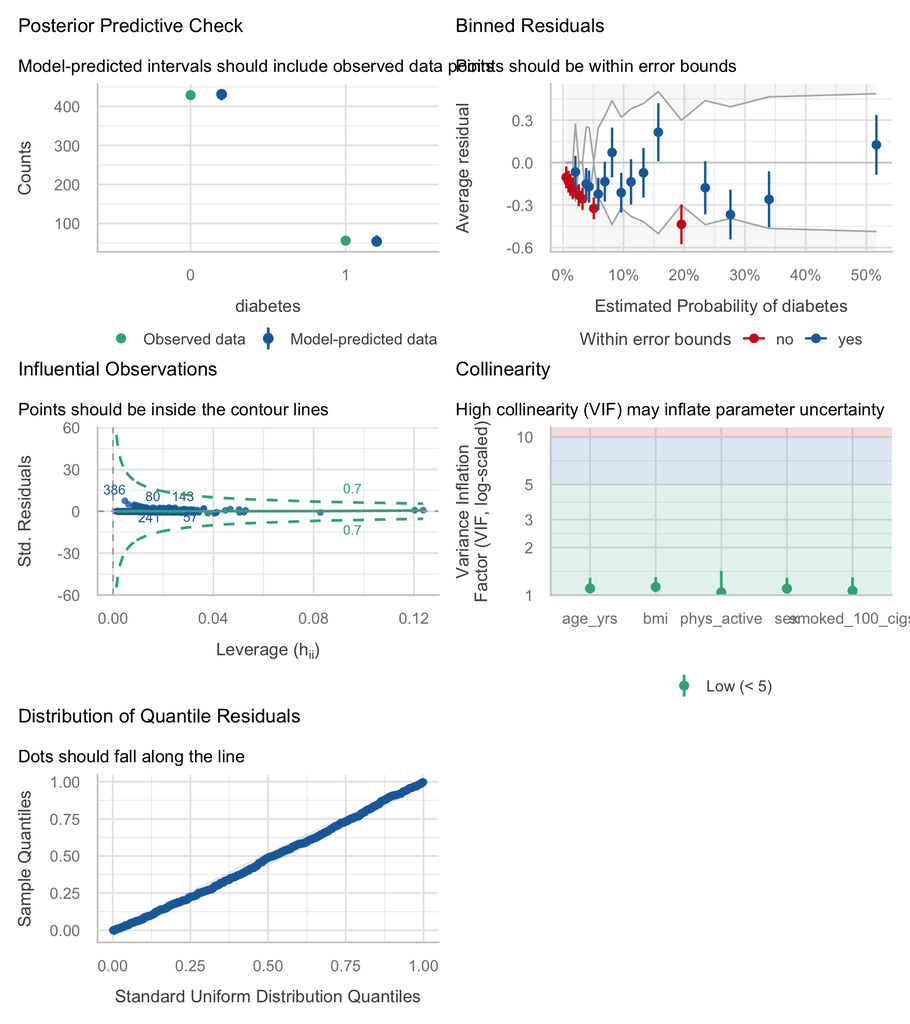

| Term | VIF | VIF_CI_low | VIF_CI_high | SE_factor | Tolerance | Tolerance_CI_low | Tolerance_CI_high |
| --- | --- | --- | --- | --- | --- | --- | --- |
| age_yrs | 1.103869 | 1.037576 | 1.287113 | 1.050651 | 0.9059050 | 0.7769328 | 0.9637844 |
| sex | 1.100367 | 1.035259 | 1.285703 | 1.048984 | 0.9087880 | 0.7777847 | 0.9659423 |
| bmi | 1.126184 | 1.052978 | 1.300548 | 1.061218 | 0.8879541 | 0.7689065 | 0.9496874 |
| phys_active | 1.039922 | 1.003750 | 1.425026 | 1.019766 | 0.9616103 | 0.7017416 | 0.9962641 |
| smoked_100_cigs | 1.065881 | 1.014668 | 1.295901 | 1.032415 | 0.9381911 | 0.7716640 | 0.9855439 |

The binned-residual check is the one that matters here, and it is **not reassuring**: only about 64% of binned residuals fall inside the error bounds, against a target of 95% or more. With 56 events spread across 485 observations, each bin holds very few events, so the check is itself noisy - but the pattern is consistent with the linear-in-log-odds assumption for age and BMI being imperfect at the extremes, where predicted probabilities are very small. Collinearity is not a problem: all VIFs are below 1.2, so the age, BMI and activity coefficients are not competing for the same variance. No observation exceeds the influence contours (maximum Cook’s distance 0.044), and the largest leverage is 0.124, so no single participant drives the fit. There is no separation: every predictor has finite coefficients and standard errors below 1.15, and both levels of each binary predictor contain events. Homogeneity of variance and normality of residuals do not apply to a logistic model and are not interpreted.

# Discussion

In this NHANES extract, age and BMI are independently associated with having a diabetes diagnosis, and their associations are strong: roughly 1.8-fold higher odds per decade of age and 1.7-fold per 5 kg/m2 of BMI, each holding the other constant. The crude protective association with recreational physical activity is largely explained by activity being commoner in younger and leaner participants and does not survive adjustment. Practically, this supports age and BMI as the primary screening axes and cautions against reading a crude activity-diabetes contrast as evidence that exercise prevents diabetes.

**Limitations.** The models are unweighted, and the NHANES sampling weights, strata and PSUs are not in this extract, so the sample **must not be described as nationally representative**. The outcome is *self-reported diagnosis*, not measured glycaemia: undiagnosed diabetes is misclassified as non-diabetic, and because undiagnosed diabetes is commoner in younger people and those with less contact with health services, this misclassification is differential with respect to age and income - a serious bias in the direction of exaggerating the age association. The design is cross-sectional, so reverse causation is entirely plausible for BMI and activity: people diagnosed with diabetes are advised to lose weight and exercise, which would attenuate both associations. With only 56 events the model could carry no more than five parameters, so race/ethnicity, education and family history - all relevant - are omitted and residual confounding is certain. The binned-residual check flags poor calibration. Complete-case analysis dropped only 3 rows here, but that is a consequence of the deliberately small predictor set, not of the file being complete. All estimates are associations, not causal effects.

**Future work.** Refit with the NHANES survey design and with measured HbA1c or fasting glucose to capture undiagnosed diabetes, which would remove the dominant misclassification problem.

# Feasibility notes

*NOT part of a student report.*

- **Viable, but tightly constrained by the event count.** 57 events in the file, 56 in the analytic sample, supporting about **five parameters at ten events per parameter**. The model here uses exactly five (EPP = 11.2). A student who throws in `race` (4 df) and `education` (4 df) will be at 13 parameters and EPP ~4.3, which is over-fitting regardless of what the p-values say. This must be stated explicitly in the brief.
- **No separation at this predictor set** - all coefficients finite, max SE 1.15, max VIF 1.13.
- **FATAL if `race` is added: complete separation.** The “Other” stratum has **0 diabetes events in 25 participants** (Hispanic has 3, Mexican 4). Adding `race` to this model produces a `raceOther` coefficient of about -14 with a standard error of about 729 - textbook separation - alongside a “fitted probabilities numerically 0 or 1” warning. This is the single most likely way a student wrecks this outcome, and it is also a second, independent reason for the five-parameter cap.
- **MAJOR: binned residuals fail** (~64% inside bounds vs 95% target). Partly an artefact of few events per bin, partly genuine miscalibration. A student following the diagnostics honestly will have to report a failed check.
- **MAJOR conceptual problem: the outcome is self-reported *diagnosis*, not diabetes.** Undiagnosed cases are counted as non-cases, and this is differential by age and healthcare access. Strong students will spot it; weak ones will write “age causes diabetes”.
- **Reverse causation is severe.** BMI and physical activity are both plausibly *consequences* of a diabetes diagnosis in a cross-sectional file. The activity finding is uninterpretable causally.
- **Complete-case N 485 of 488** - the mildest attrition of any outcome here, but only because the predictor set had to be small. Any predictor with real missingness (`poverty_ratio`, `general_health`, `alcohol_days_year`) costs both rows *and* events.
- **Trap: `obese` and `bmi` are the same variable.** `obese` is exactly `bmi >= 30`; never put both in this model.
- **Unweighted survey analysis.** Must be stated.